# Biomechanical analysis of pedicle screw reinsertion along the same trajectory in a 3D printed synthetic bone model

Authors

Affiliations

Graham Mulvaney, MD

Atrium Health’s Carolinas Medical Center, 1000 Blythe Blvd, Charlotte, NC 28204

Michael A. Bohl, MD

Carolina Neurosurgery & Spine Associates, 225 Baldwin Ave, Charlotte, NC 28204

Published

July 30, 2023

# Introduction

Pedicle screw fixation has been utilized in an increasing manner for the surgical management of various spine diseases since it’s general adoption in the 1990s. Key early studies evaluating their effectiveness and robustness have remained a steady undercurrent of the steady advancements that have enabled expansions of use and the extension of meaningful surgical correction of increasingly complex pathologies. Outside of clinical trials, the most instrumental and influential studies have sought to define the biomechanical parameters that can most effectively be augmented to increase their effectiveness. Studies have since identified and centered around maximizing screw purchase within the bone, decreasing the propensity for the screw to break, and decreasing the chance for the screw to pullout of the bone or loosen. These are the most common failure points for screw-rod constructs and are known to lead to both pseudoarthrosis and mechanical back pain, often leading to the need for revision surgery or extension of constructs.

The pullout strength of a screw is a biomechanical parameter that encompasses all of these principles in a meaningful way. Additional measures that have been previously analyzed for correlation to pullout strength include the stiffness of the construct, which is a measure of a screws resistance to deformation, the insertional torque (a sign of increased screw purchase), and the strain energy associated with removal (useful to compare for screw constructs of varying stiffness).

These fundamental biomechanics underpinning pedicle screw fixation have been investigated for decades. Among the investigations of these fundamental studies have directly led to innovations including cement augmentation, cortical bone trajectory placement, and a plethora of screw and tulip head variations. Since these initial breakthroughs however, impactful biomechanical studies have decreased and meaningful results have diminished. The rate of surgical device innovation has only accelerated in the meantime, and with the increasing implementation and evolution of techniques such as navigated systems, it is clear that an improved model with better reproducibility and generalizability is necessary. Additionally with the forecasted wave of osteoporosis and metastatic tumor due to increasing patient age and survivability with cancer diagnoses, we can expect an increased number of screw adjustments and revisions from initially poor placement in the coming years as surgeons adapt to new learning curves.

With these coming tribulations, there are new critical questions that will arise that are lacking a clear paradigm for investigating. An example of this question is, regardless of technique placing a screw, if a surgeon places a screw, removes said screw to assess the integrity of the pedicle, and finding it suitable, places the screw back into place via the same trajectory and angle, is this screw inherently weaker? This question has been investigated by only a handful of biomechanics labs, which should be lauded for continuing this research and providing compelling evidence of their results in varying substrate. However, the inherent cost of these models, the lack of generalizability, and ultimately the wide variation in the primary outcomes of each study makes it incredibly difficult to correct for sampling bias and to reject the null hypothesis.

A novel 3D printed model of a lumbar vertebral body has previously been validated, with demonstrations of similar resistance to load, closer reproduction of screw placement feel, as well as possessing a generalizabilty to the population at large in an increasingly globalized world with ready access to 3D printers. This study aims to provide a robust analysis of the biomechanics of pedicle screw reinsertion, and we hypothesize that there is no difference in strength when the reinsertion trajectory is the same.

# Methods

Utilizing twenty of these models, a control arm and a testing arm were created. In the control arm. A screw was inserted to depth, then forcibly removed. In the testing arm. A screw was inserted to depth, removed in controlled fashion, reinserted to same depth, then forcibly removed through direct force applied along the same trajectory as insertion.

The methods and standards set by this biomechanics lab were previously commented on previous publication detailing the validation of this biomechanics lab.

# Results

## Figures

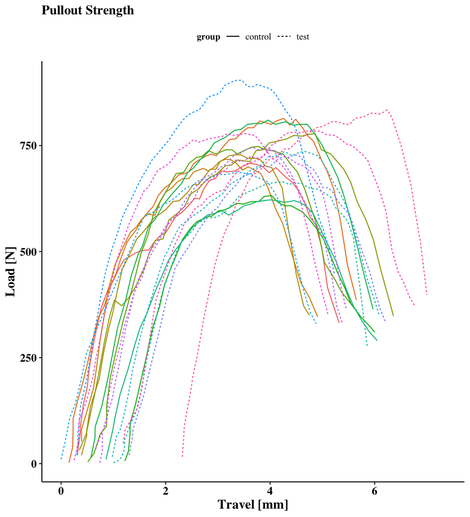

Figure 1: Individual Force-Displacement Tests

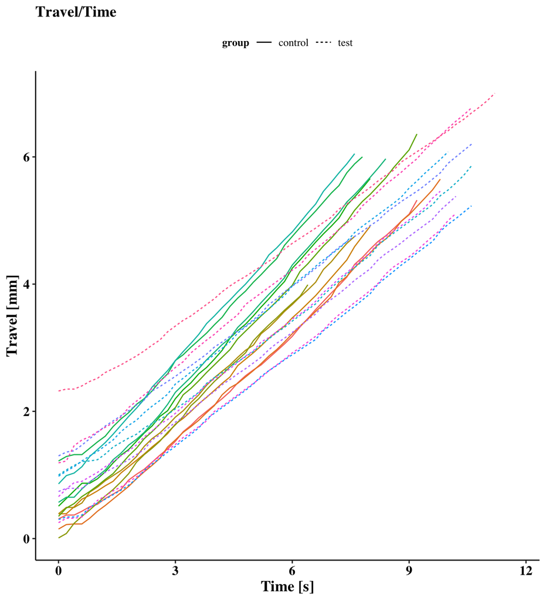

Figure 2: Consistent Displacement/Time

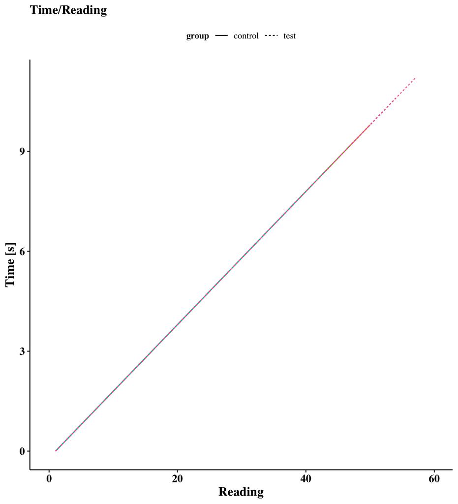

Figure 3: Consistent Sampling Rate

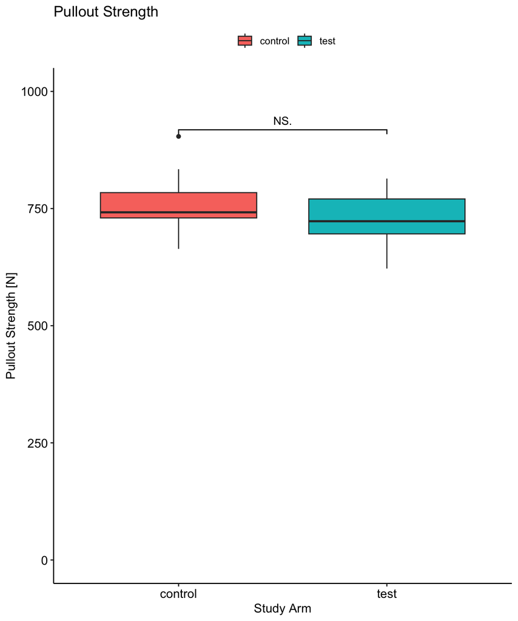

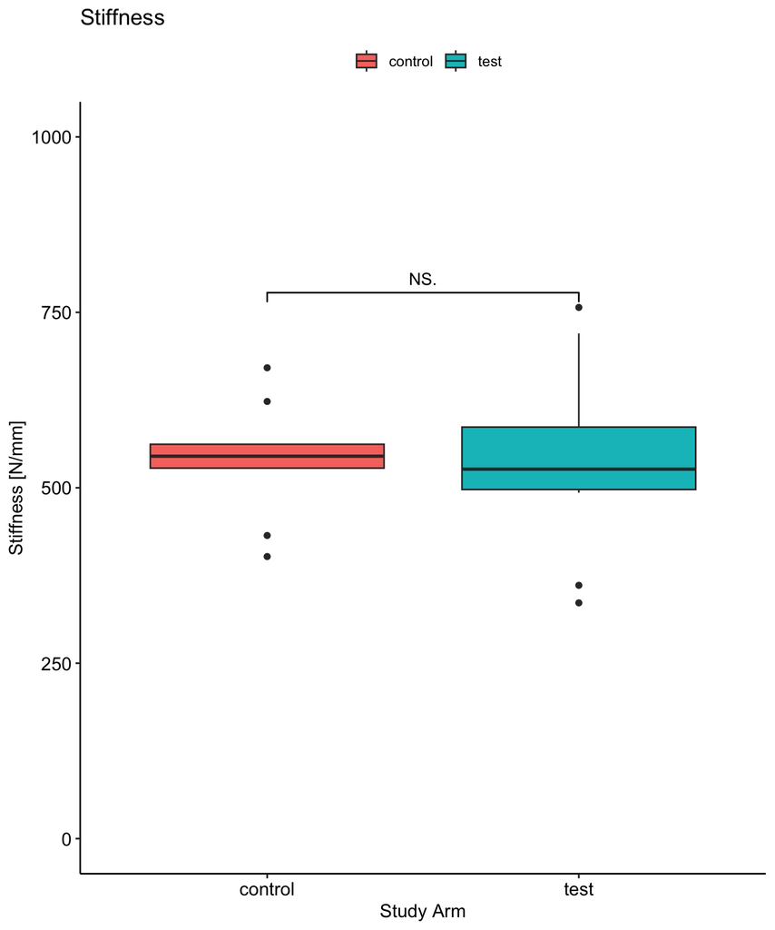

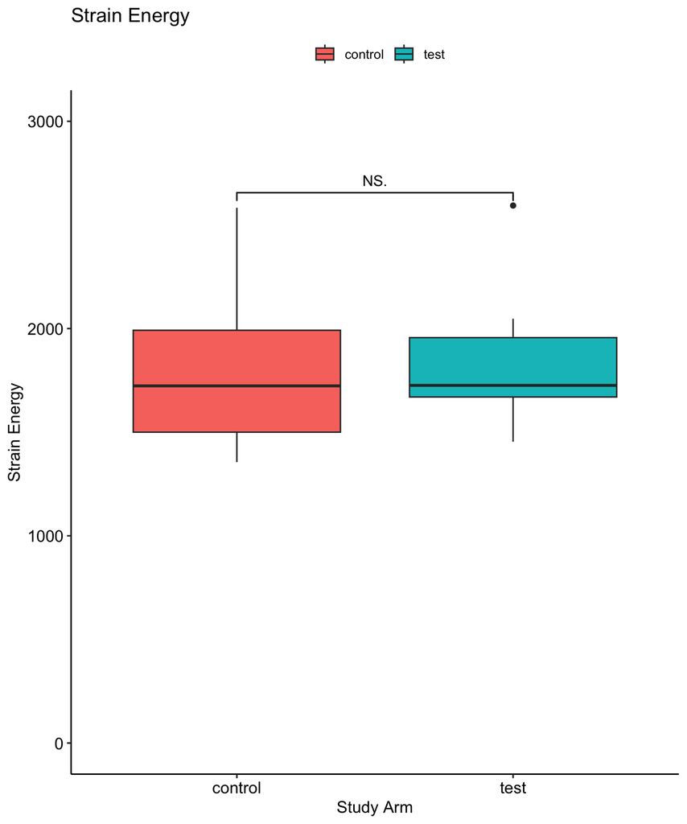